# Ch 5: Linear Models

## Spurious association

Correlation between marriage and divorce

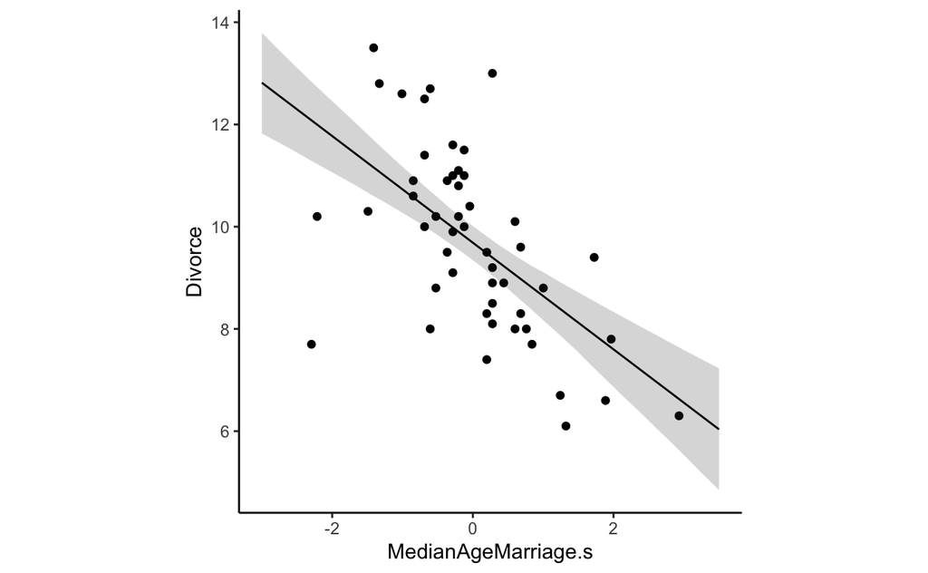

```r
library(cowplot)
library(rethinking)
library(tidyverse)
# data
data(WaffleDivorce)
z <- function(x) (x - mean(x)) / sd(x)
d <- WaffleDivorce %>%
  mutate(MedianAgeMarriage.s = z(MedianAgeMarriage),
         Marriage.s = z(Marriage))

# model
m5.1 <- rethinking::map(
  alist(
    Divorce ~ dnorm(mu, sigma),
    mu <- a + bA * MedianAgeMarriage.s,
    a ~ dnorm(10, 10),
    bA ~ dnorm(0, 1),
    sigma ~ dunif(0, 10)
  ),
  data = d
)

# plot
MAM.seq <- seq(-3, 3.5, length.out = 30)
mu <- link(m5.1, data = data.frame(MedianAgeMarriage.s = MAM.seq))
mu.mean <- apply(mu, 2, mean)
mu.PI <- apply(mu, 2, PI)

pred_tbl <- tibble(
  MedianAgeMarriage.s = MAM.seq,
  Divorce = mu.mean,
  Divorce_low = mu.PI[1, ],
  Divorce_high = mu.PI[2, ]
)

ggplot(d, aes(MedianAgeMarriage.s, Divorce)) +
  geom_point() +
  geom_ribbon(aes(ymin = Divorce_low, ymax = Divorce_high),
              pred_tbl,
              alpha = 0.2) +
  geom_line(data = pred_tbl) +
  theme_classic() +
  theme(aspect.ratio = 1)
```

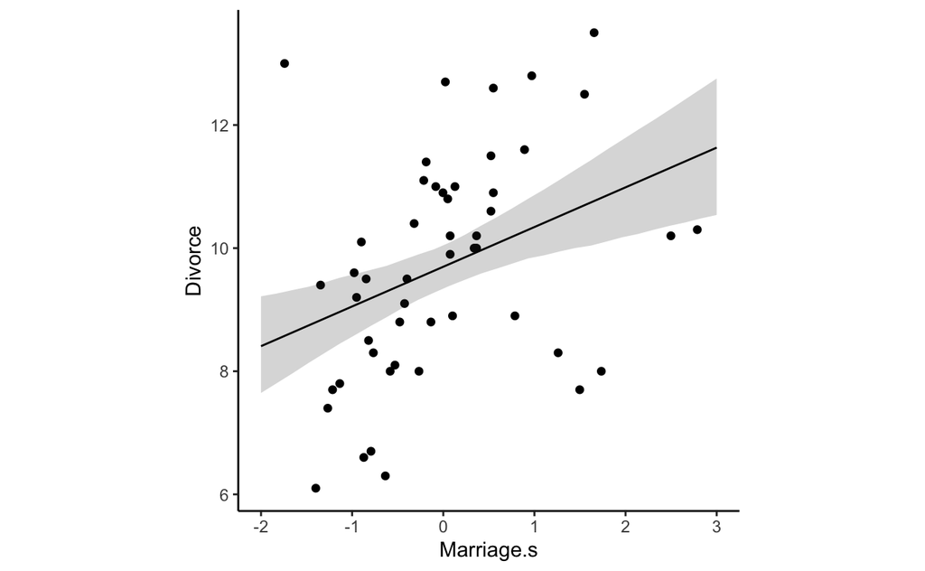

```r
# model
m5.2 <- rethinking::map(
  alist(
    Divorce ~ dnorm(mu, sigma),
    mu <- a + bR * Marriage.s,
    a ~ dnorm(10, 10),
    bR ~ dnorm(0, 1),
    sigma ~ dunif(0, 10)
  ),
  data = d
)

# plot
mar.seq <- seq(-2, 3, length.out = 30)
mu <- link(m5.2, data = data.frame(Marriage.s = mar.seq))
mu.mean <- apply(mu, 2, mean)
mu.PI <- apply(mu, 2, PI)

pred_tbl <- tibble(
  Marriage.s = mar.seq,
  Divorce = mu.mean,
  Divorce_low = mu.PI[1, ],
  Divorce_high = mu.PI[2, ]
)

ggplot(d, aes(Marriage.s, Divorce)) +
  geom_point() +
  geom_ribbon(aes(ymin = Divorce_low, ymax = Divorce_high),
              pred_tbl,
              alpha = 0.2) +
  geom_line(data = pred_tbl) +
  theme_classic() +
  theme(aspect.ratio = 1)
```

Specifying a multivariate model
$$D_i \sim \mathcal{N}(\mu_i, \sigma) \\
\mu_i = \alpha + \beta_R R_i + \beta_A A_i \\
\alpha \sim \mathcal{N}(10, 10) \\
\beta_R \sim \mathcal{N}(0, 1) \\
\beta_A \sim \mathcal{N}(0, 1) \\
\sigma \sim \mathcal{U}(0, 10)$$

```r
m5.3 <- rethinking::map(
  alist(
    Divorce ~ dnorm(mu, sigma),
    mu <- a + bR * Marriage.s + bA * MedianAgeMarriage.s,
    a ~ dnorm(10, 10),
    bR ~ dnorm(0, 1),
    bA ~ dnorm(0, 1),
    sigma ~ dunif(0, 10)
  ),
  data = d
)
precis(m5.3)
```

|  | mean | sd | 5.5% | 94.5% |
| --- | --- | --- | --- | --- |
| a | 9.69 | 0.20 | 9.36 | 10.01 |
| bR | -0.13 | 0.28 | -0.58 | 0.31 |
| bA | -1.13 | 0.28 | -1.58 | -0.69 |
| sigma | 1.44 | 0.14 | 1.21 | 1.67 |

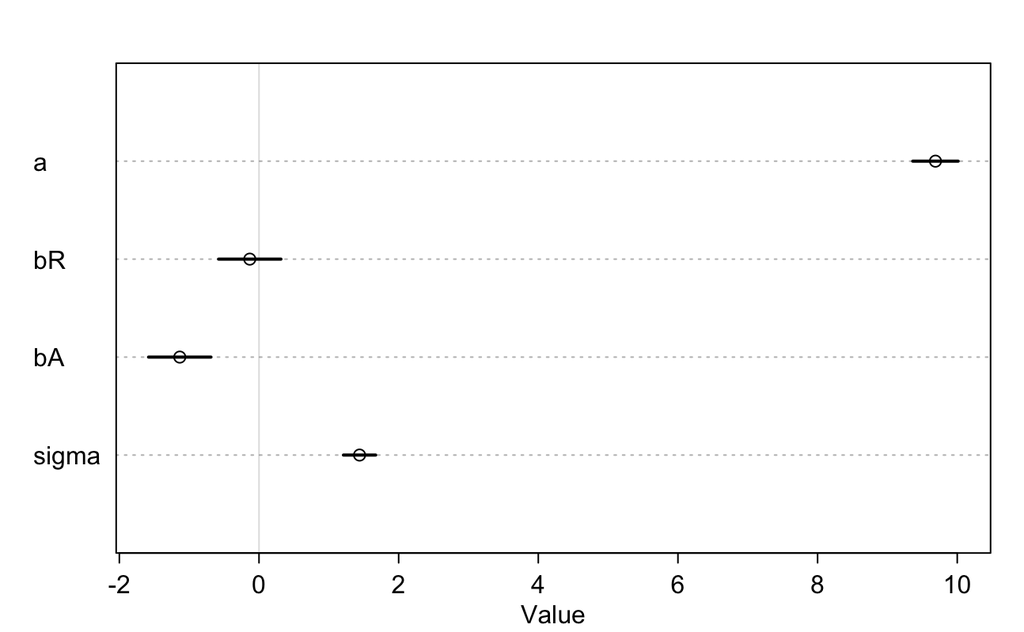

```r
plot(precis(m5.3))
```

### Plotting multivariate posteriors

#### Predictor residual plots

First, the residual of one predictor w.r.t. the other

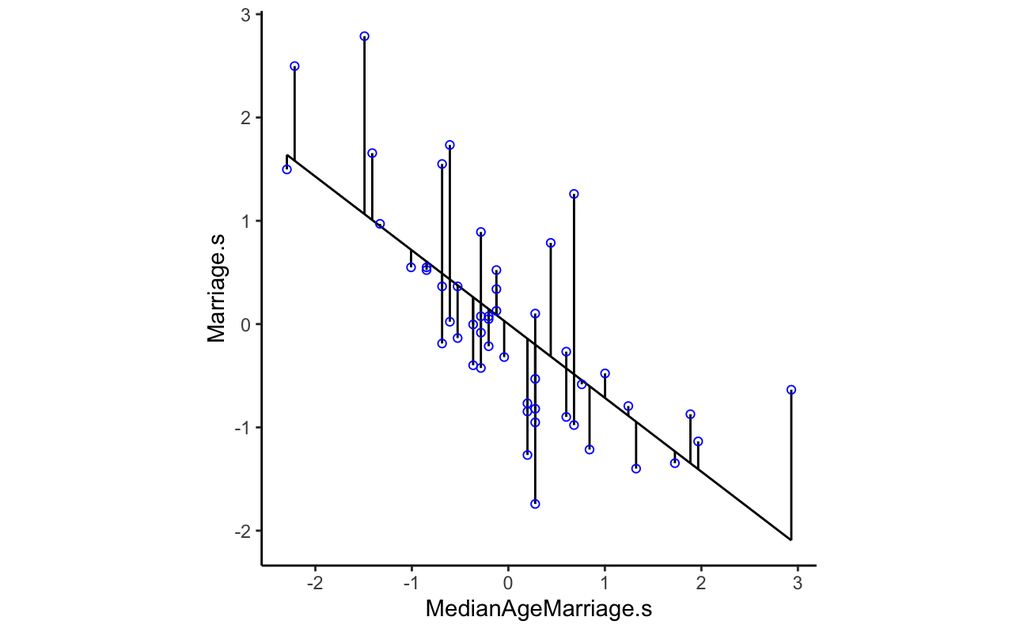

```r
m5.4 <- rethinking::map(
  alist(
    Marriage.s ~ dnorm(mu, sigma),
    mu <- a + b * MedianAgeMarriage.s,
    a ~ dnorm(0, 10),
    b ~ dnorm(0, 1),
    sigma ~ dunif(0, 10)
  ),
  data = d
)

# compute expected value at MAP, for each State
mu <- coef(m5.4)['a'] + coef(m5.4)['b'] * d$MedianAgeMarriage.s
# compute residuals
m.resid <- d$Marriage.s - mu

# plot residuals
R_resid_tbl <- tibble(
  id = rep(d$Location, 2),
  MedianAgeMarriage.s = rep(d$MedianAgeMarriage.s, 2),
  Marriage.s = c(mu, d$Marriage.s)
)
mu_tbl <- tibble(
  MedianAgeMarriage.s = range(d$MedianAgeMarriage.s),
  Marriage.s = coef(m5.4)['a'] + coef(m5.4)['b'] * MedianAgeMarriage.s
)
ggplot(d, aes(MedianAgeMarriage.s, Marriage.s)) +
  geom_line(data = mu_tbl) +
  geom_line(aes(group = id), R_resid_tbl) +
  geom_point(color = "blue", shape = 21) +
  theme_classic() +
  theme(aspect.ratio = 1)
```

#### Counterfactual plots

```r
# prepare counterfactual data
A.avg <- mean(d$MedianAgeMarriage.s)
R.seq <- seq(-3, 3, length.out = 30)
pred.data <- tibble(
  Marriage.s = R.seq,
  MedianAgeMarriage.s = A.avg
)

# compute counterfactual mean divorce (mu)
mu <- link(m5.3, data = pred.data)
mu.mean <- apply(mu, 2, mean)
mu.PI <- apply(mu, 2, PI)

# simulate counterfactual divorce outcomes
R.sim <- sim(m5.3, data = pred.data, n = 1e4)
R.PI <- apply(R.sim, 2, PI)

# display predictions, hiding raw data with type = "n"
plot(Divorce ~ Marriage.s, data = d, type = "n")
mtext("MedianAgeMarriage.s = 0")
```

```r
lines(R.seq, mu.mean)
shade(mu.PI, R.seq)
```

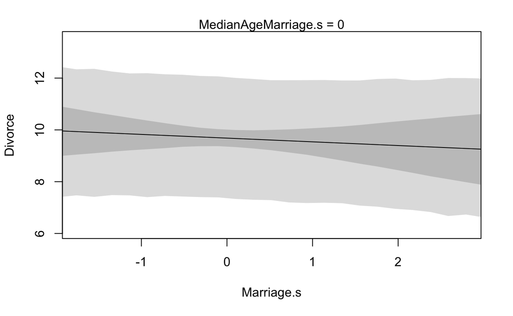

```r
shade(R.PI, R.seq)
```

#### Posterior prediction plots

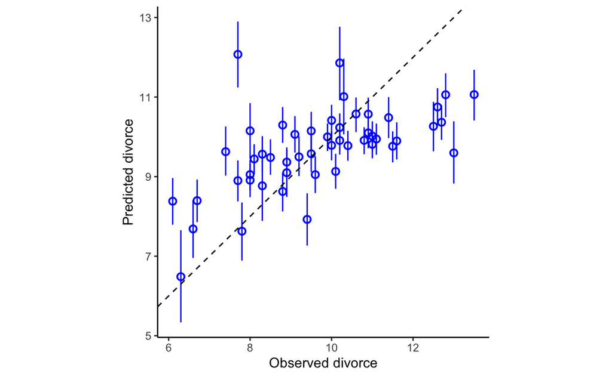

```r
#call link without specifying new data so it uses original data
mu <- link(m5.3)

# summarize samples across cases
mu.mean <- apply(mu, 2, mean)
mu.PI <- apply(mu, 2, PI)

# simulate observations
# again no new data, so uses original data
divorce.sim <- sim(m5.3, n = 1e4)
divorce.PI <- apply(divorce.sim, 2, PI)

post_pred <- tibble(
  state = d$Location,
  divorce = d$Divorce,
  mu.mean,
  mu.low = mu.PI[1, ],
  mu.hi = mu.PI[2, ],
  divorce.low = divorce.PI[1, ],
  divorce.hi = divorce.PI[2, ],
  resid = divorce - mu.mean,
  resid.low = divorce - divorce.low,
  resid.hi = divorce - divorce.hi
)

ggplot(post_pred, aes(divorce, mu.mean, ymin = mu.low, ymax = mu.hi)) +
  geom_pointrange(shape = 21, color = "blue") +
  geom_abline(slope = 1, intercept = 0, linetype = 2) +
  labs(x = "Observed divorce",
       y = "Predicted divorce") +
  theme_classic() +
  theme(aspect.ratio = 1)
```

Now plot error for each state

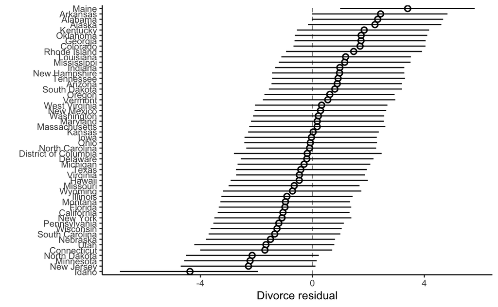

```r
post_pred %>%
  mutate(state = fct_reorder(factor(state), resid)) %>%
  ggplot(aes(state, resid, ymin = resid.low, ymax = resid.hi)) +
  geom_hline(yintercept = 0, linetype = 2, alpha = 0.5) +
  geom_pointrange(shape = 21) +
  coord_flip() +
  labs(x = "", y = "Divorce residual") +
  theme_classic()
```

Spurious data example. Note the 89% PI for $b_{real}$ overlaps 1 and for $B_{spur}$ overlaps 0.

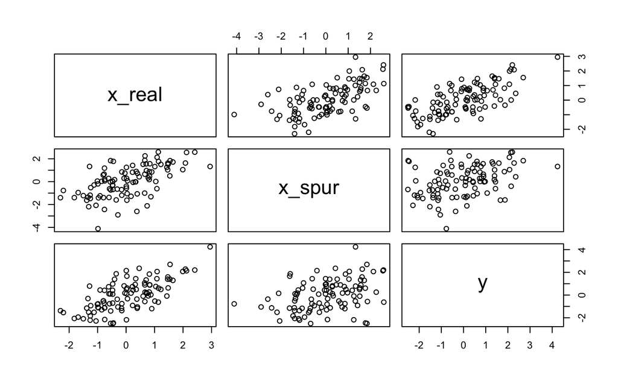

```r
N <- 1e2
x_real <- rnorm(N)
x_spur <- rnorm(N, x_real)
y <- rnorm(N, x_real)
d <- tibble(x_real, x_spur, y)
pairs(d)
```

```r
m.spur <- rethinking::map(
  alist(
    y ~ dnorm(mu, sigma),
    mu <- a + bR * x_real + bS * x_spur,
    a ~ dnorm(10, 10),
    bR ~ dnorm(0, 1),
    bS ~ dnorm(0, 1),
    sigma ~ dunif(0, 10)
  ),
  data = d
)
precis(m.spur)
```

|  | mean | sd | 5.5% | 94.5% |
| --- | --- | --- | --- | --- |
| a | -0.05 | 0.10 | -0.21 | 0.10 |
| bR | 0.94 | 0.12 | 0.75 | 1.12 |
| bS | -0.05 | 0.09 | -0.19 | 0.10 |
| sigma | 0.97 | 0.07 | 0.86 | 1.08 |

## Masked relationship

```r
data(milk)
d <- milk %>%
  drop_na(neocortex.perc)
str(d)
```

```
'data.frame':   17 obs. of  8 variables:
 $ clade         : Factor w/ 4 levels "Ape","New World Monkey",..: 4 2 2 2 2 2 2 2 3 3 ...
 $ species       : Factor w/ 29 levels "A palliata","Alouatta seniculus",..: 11 2 1 6 27 5 3 4 21 19 ...
 $ kcal.per.g    : num  0.49 0.47 0.56 0.89 0.92 0.8 0.46 0.71 0.68 0.97 ...
 $ perc.fat      : num  16.6 21.2 29.7 53.4 50.6 ...
 $ perc.protein  : num  15.4 23.6 23.5 15.8 22.3 ...
 $ perc.lactose  : num  68 55.2 46.9 30.8 27.1 ...
 $ mass          : num  1.95 5.25 5.37 2.51 0.68 0.12 0.47 0.32 1.55 3.24 ...
 $ neocortex.perc: num  55.2 64.5 64.5 67.6 68.8 ...
```

```r
m5.5 <- rethinking::map(
  alist(
    kcal.per.g ~ dnorm(mu, sigma),
    mu <- a + bn * neocortex.perc,
    a ~ dnorm(0, 100),
    bn ~ dnorm(0, 1),
    sigma ~ dunif(0, 1)
  ),
  data = d
)

precis(m5.5, digits = 3)
```

|  | mean | sd | 5.5% | 94.5% |
| --- | --- | --- | --- | --- |
| a | 0.353 | 0.471 | -0.399 | 1.106 |
| bn | 0.005 | 0.007 | -0.007 | 0.016 |
| sigma | 0.166 | 0.028 | 0.120 | 0.211 |

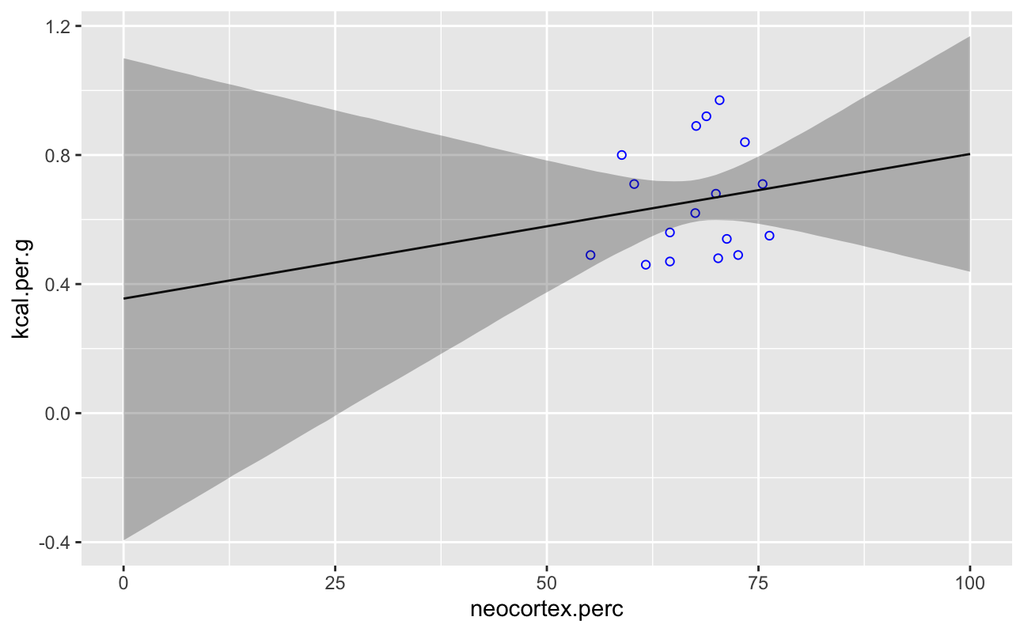

```r
np.seq <- 0:100

mu <- link(m5.5, data = tibble(neocortex.perc = np.seq), n = 1e4)
mu.mean <- apply(mu, 2, mean)
mu.PI <- apply(mu, 2, PI)

pred.data <- tibble(
  neocortex.perc = np.seq,
  kcal.per.g = mu.mean,
  kcal.per.g.low = mu.PI[1, ],
  kcal.per.g.hi = mu.PI[2, ]
)

ggplot(d, aes(neocortex.perc, kcal.per.g)) +
  geom_point(shape = 21, color = "blue") +
  geom_line(data = pred.data) +
  geom_ribbon(aes(ymin = kcal.per.g.low, ymax = kcal.per.g.hi),
              pred.data,
              alpha = 0.3)
```

```r
d2 <- mutate(d, log.mass = log(mass))

m5.6 <- rethinking::map(
  alist(
    kcal.per.g ~ dnorm(mu, sigma),
    mu <- a + bm * log.mass,
    a ~ dnorm(0, 100),
    bm ~ dnorm(0, 1),
    sigma ~ dunif(0, 1)
  ),
  data = d2
)
precis(m5.6)
```

|  | mean | sd | 5.5% | 94.5% |
| --- | --- | --- | --- | --- |
| a | 0.71 | 0.05 | 0.63 | 0.78 |
| bm | -0.03 | 0.02 | -0.06 | 0.00 |
| sigma | 0.16 | 0.03 | 0.11 | 0.20 |

So we see two variables with weakly contrasting effects: kcal per g barely increases with neocortex percentage and barely decreases with log mass. So the two variables are masking each other’s influence and bivariate regression is misleading. A multivariate regression revelas how strong the effect actually is.

```r
m5.7 <- rethinking::map(
  alist(
    kcal.per.g ~ dnorm(mu, sigma),
    mu <- a + bn * neocortex.perc + bm * log.mass,
    a ~ dnorm(0, 100),
    bn ~ dnorm(0, 1),
    bm ~ dnorm(0, 1),
    sigma ~ dunif(0, 1)
  ),
  data = d2
)

precis(m5.7)
```

|  | mean | sd | 5.5% | 94.5% |
| --- | --- | --- | --- | --- |
| a | -1.08 | 0.47 | -1.83 | -0.34 |
| bn | 0.03 | 0.01 | 0.02 | 0.04 |
| bm | -0.10 | 0.02 | -0.13 | -0.06 |
| sigma | 0.11 | 0.02 | 0.08 | 0.15 |

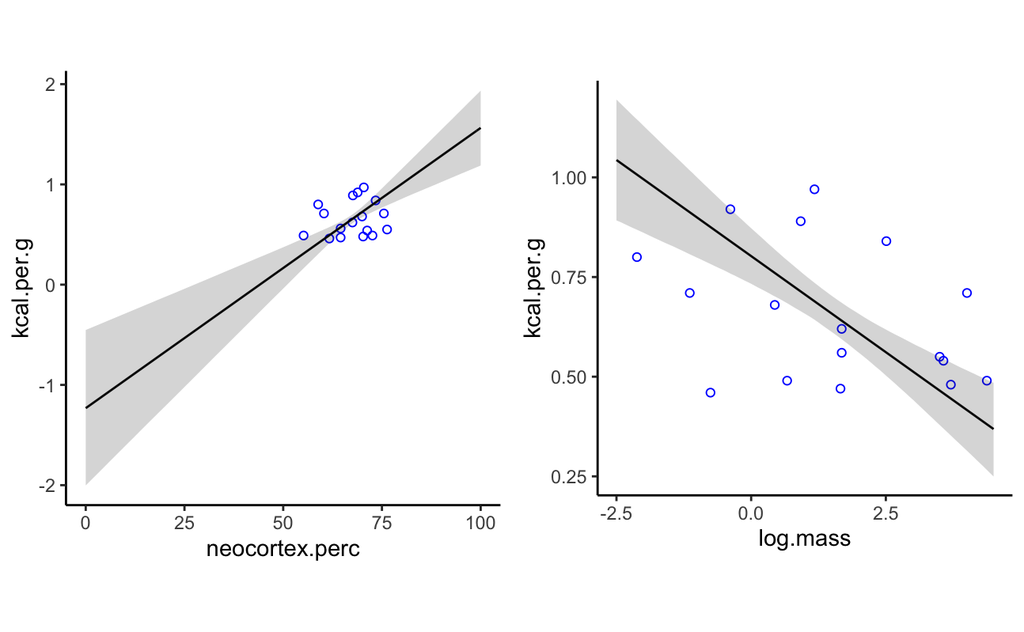

```r
# Vary neocortex percent but keep log.mass fixed
mean.log.mass <- mean(log(d2$mass))
np.seq <- 0:100
pred.data1 <- data.frame(
  neocortex.perc = np.seq,
  log.mass = mean.log.mass
)

mu <- link(m5.7, data = pred.data1, n = 1e4)
mu.mean <- apply(mu, 2, mean)
mu.PI <- apply(mu, 2, PI)

pred.data1$kcal.per.g <- mu.mean
pred.data1$kcal.per.g.low <- mu.PI[1, ]
pred.data1$kcal.per.g.hi <- mu.PI[2, ]

# And vice versa
mean.np <- mean(d2$neocortex.perc)
log.mass.seq <- seq(-2.5, 4.5, length.out = 100)
pred.data2 <- data.frame(
  neocortex.perc = mean.np,
  log.mass = log.mass.seq
)

mu <- link(m5.7, data = pred.data2, n = 1e4)
mu.mean <- apply(mu, 2, mean)
mu.PI <- apply(mu, 2, PI)

pred.data2$kcal.per.g <- mu.mean
pred.data2$kcal.per.g.low <- mu.PI[1, ]
pred.data2$kcal.per.g.hi <- mu.PI[2, ]


plot_grid(
  ggplot(d2, aes(neocortex.perc, kcal.per.g), d2) +
    geom_point(shape = 21, color = "blue") +
    geom_line(data = pred.data1) +
    geom_ribbon(aes(ymin = kcal.per.g.low, ymax = kcal.per.g.hi),
                pred.data1,
                alpha = 0.2) +
    theme_classic() +
    theme(aspect.ratio = 1),
  ggplot(d2, aes(log.mass, kcal.per.g), d2) +
    geom_point(shape = 21, color = "blue") +
    geom_line(data = pred.data2) +
    geom_ribbon(aes(ymin = kcal.per.g.low, ymax = kcal.per.g.hi),
                pred.data2,
                alpha = 0.2) +
    theme_classic() +
    theme(aspect.ratio = 1),
  nrow = 1
)
```

## When adding variables hurts

### Multicollinear legs

```r
N <- 100

d <- tibble(
  height = rnorm(N, 10, 2),
  leg_prop = runif(N, 0.4, 0.5),
  leg_left = leg_prop * height + rnorm(N, 0, 0.02),
  leg_right = leg_prop * height + rnorm(N, 0, 0.02)
)

m5.8 <- rethinking::map(
  alist(
    height ~ dnorm(mu, sigma),
    mu <- a + bl * leg_left + br * leg_right,
    a ~ dnorm(10, 100),
    bl ~ dnorm(2, 10),
    br ~ dnorm(2, 10),
    sigma ~ dunif(0, 10)
  ),
  data = d
)

precis(m5.8)
```

|  | mean | sd | 5.5% | 94.5% |
| --- | --- | --- | --- | --- |
| a | 0.91 | 0.29 | 0.44 | 1.37 |
| bl | -1.24 | 1.89 | -4.26 | 1.78 |
| br | 3.28 | 1.90 | 0.24 | 6.31 |
| sigma | 0.58 | 0.04 | 0.51 | 0.65 |

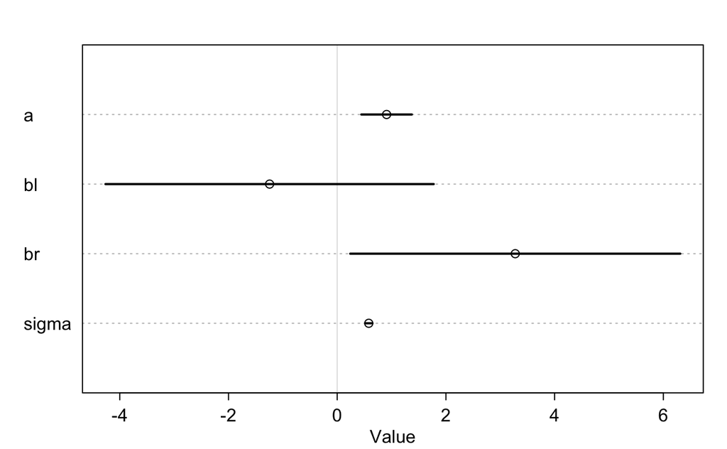

```r
plot(precis(m5.8))
```

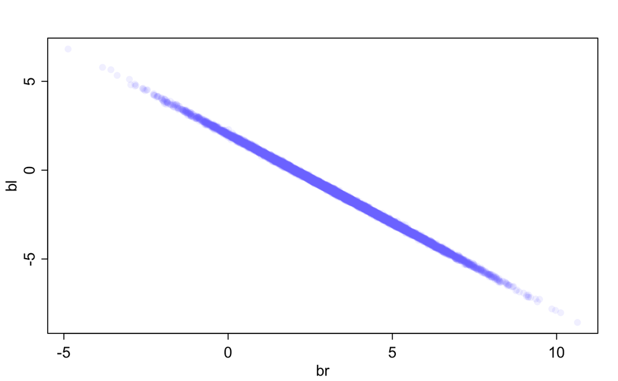

```r
post <- extract.samples(m5.8)
plot(bl ~ br, post, col = col.alpha(rangi2, 0.1), pch = 16)
```

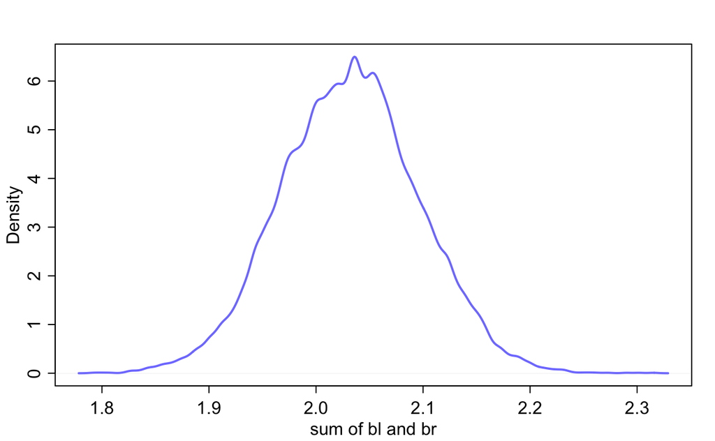

```r
sum_blbr <- post$bl + post$br
dens(sum_blbr, col = rangi2, lwd = 2, xlab = "sum of bl and br")
```

```r
m5.9 <- rethinking::map(
  alist(
    height ~ dnorm(mu, sigma),
    mu <- a + bl * leg_left,
    a ~ dnorm(10, 100),
    bl ~ dnorm(2, 10),
    sigma ~ dunif(0, 10)
  ),
  data = d
)

precis(m5.9)
```

|  | mean | sd | 5.5% | 94.5% |
| --- | --- | --- | --- | --- |
| a | 0.99 | 0.29 | 0.53 | 1.46 |
| bl | 2.01 | 0.06 | 1.91 | 2.12 |
| sigma | 0.59 | 0.04 | 0.52 | 0.66 |

### Multicollinear milk

```r
d <- milk
#kcal.per.g regressed on perc.fat
m5.10 <- rethinking::map(
  alist(
    kcal.per.g ~ dnorm(mu, sigma),
    mu <- a + bf * perc.fat,
    a ~ dnorm(0.6, 10),
    bf ~ dnorm(0, 1),
    sigma ~ dunif(0, 10)
  ),
  data = d
)
# kcal.per.g regressed on perc.lactose
m5.11 <- rethinking::map(
  alist(
    kcal.per.g ~ dnorm(mu, sigma),
    mu <- a + bl * perc.lactose,
    a ~ dnorm(0.6, 10),
    bl ~ dnorm(0, 1),
    sigma ~ dunif(0, 10)
  ),
  data = d
)

precis(m5.10, digits = 3)
```

|  | mean | sd | 5.5% | 94.5% |
| --- | --- | --- | --- | --- |
| a | 0.301 | 0.036 | 0.244 | 0.358 |
| bf | 0.010 | 0.001 | 0.008 | 0.012 |
| sigma | 0.073 | 0.010 | 0.058 | 0.089 |

```r
precis(m5.11, digits = 3)
```

|  | mean | sd | 5.5% | 94.5% |
| --- | --- | --- | --- | --- |
| a | 1.166 | 0.043 | 1.098 | 1.235 |
| bl | -0.011 | 0.001 | -0.012 | -0.009 |
| sigma | 0.062 | 0.008 | 0.049 | 0.075 |

```r
m5.12 <- rethinking::map(
  alist(
    kcal.per.g ~ dnorm(mu, sigma),
    mu <- a + bf * perc.fat + bl * perc.lactose,
    a ~ dnorm(0.6, 10),
    bf ~ dnorm(0, 1),
    bl ~ dnorm(0, 1),
    sigma ~ dunif(0, 10)
  ),
  data = d
)
precis(m5.12, digits = 3)
```

|  | mean | sd | 5.5% | 94.5% |
| --- | --- | --- | --- | --- |
| a | 1.007 | 0.200 | 0.688 | 1.327 |
| bf | 0.002 | 0.002 | -0.002 | 0.006 |
| bl | -0.009 | 0.002 | -0.013 | -0.005 |
| sigma | 0.061 | 0.008 | 0.048 | 0.074 |

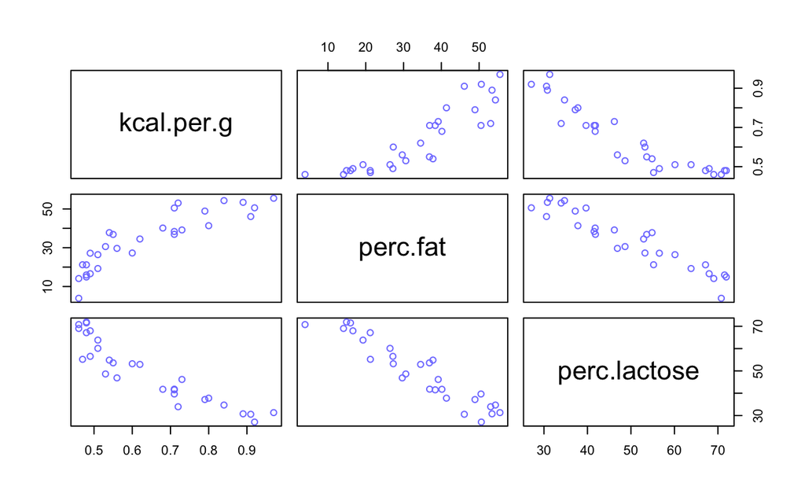

```r
pairs(~ kcal.per.g + perc.fat + perc.lactose, data = d, col = rangi2)
```

```r
cor(d$perc.fat, d$perc.lactose)
```

```
[1] -0.9416373
```

### Post-treatment bias

```r
# number of plants
N <- 100

# simulate initial heights
h0 <- rnorm(N, 10, 2)

# assign treatments and simulate fungus and growth
treatment <- rep(0:1, each = N / 2)
fungus <- rbinom(N, size = 1, prob = 0.5 - treatment * 0.4)
h1 <- h0 + rnorm(N, 5 - 3 * fungus)

d <- data.frame(h0, h1, treatment, fungus)
```

Including both treatment and presence of fungus, the coefficient for treatment is essentially 0 because it acts through controlling fungus. This model asks the wrong question.

```r
m5.13 <- rethinking::map(
  alist(
    h1 ~ dnorm(mu, sigma),
    mu <- a + bh * h0 + bt * treatment + bf * fungus,
    a ~ dnorm(0, 100),
    c(bh, bt, bf) ~ dnorm(0, 10),
    sigma ~ dunif(0, 10)
  ),
  data = d
)

precis(m5.13)
```

|  | mean | sd | 5.5% | 94.5% |
| --- | --- | --- | --- | --- |
| a | 4.12 | 0.52 | 3.29 | 4.95 |
| bh | 1.09 | 0.05 | 1.01 | 1.17 |
| bt | -0.29 | 0.23 | -0.65 | 0.08 |
| bf | -3.03 | 0.25 | -3.43 | -2.63 |
| sigma | 0.99 | 0.07 | 0.88 | 1.10 |

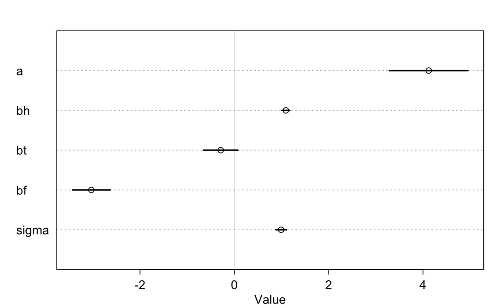

```r
plot(precis(m5.13))
```

Leaving out presence of fungus reveals the treatment had a strong effect.

```r
m5.14 <- rethinking::map(
  alist(
    h1 ~ dnorm(mu, sigma),
    mu <- a + bh * h0 + bt * treatment,
    a ~ dnorm(0, 100),
    c(bh, bt) ~ dnorm(0, 10),
    sigma ~ dunif(0, 10)
  ),
  data = d
)

precis(m5.14)
```

|  | mean | sd | 5.5% | 94.5% |
| --- | --- | --- | --- | --- |
| a | 3.33 | 0.81 | 2.03 | 4.62 |
| bh | 1.00 | 0.08 | 0.88 | 1.13 |
| bt | 1.10 | 0.31 | 0.60 | 1.59 |
| sigma | 1.56 | 0.11 | 1.38 | 1.74 |

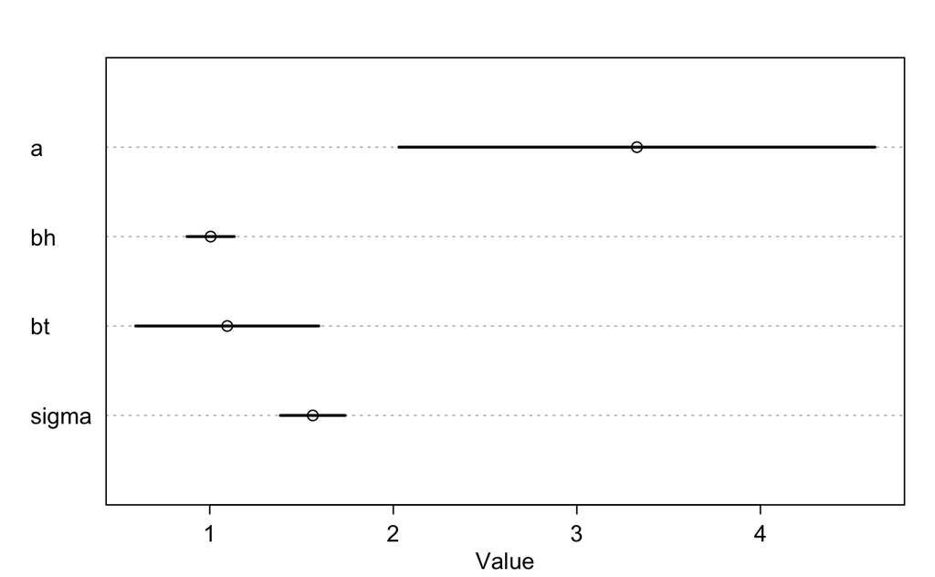

```r
plot(precis(m5.14))
```

## Categorical variables

### Binary categories

```r
data("Howell1")
d <- Howell1
str(d)
```

```
'data.frame':   544 obs. of  4 variables:
 $ height: num  152 140 137 157 145 ...
 $ weight: num  47.8 36.5 31.9 53 41.3 ...
 $ age   : num  63 63 65 41 51 35 32 27 19 54 ...
 $ male  : int  1 0 0 1 0 1 0 1 0 1 ...
```

```r
# note the categorical variable "male"

m5.15 <- rethinking::map(
  alist(
    height ~ dnorm(mu, sigma),
    mu <- a + bm * male,
    a ~ dnorm(178, 100),
    bm ~ dnorm(0, 10),
    sigma ~ dunif(0, 50)
  ),
  data = d
)

precis(m5.15)
```

|  | mean | sd | 5.5% | 94.5% |
| --- | --- | --- | --- | --- |
| a | 134.83 | 1.59 | 132.29 | 137.38 |
| bm | 7.28 | 2.28 | 3.63 | 10.93 |
| sigma | 27.31 | 0.83 | 25.99 | 28.63 |

Interpret the model as follows: is the mean height *among females*. The model is specified as $\mu_i = \alpha + \beta_m \times m_i$, so $\mu$ equals $\alpha$ when $m_i$ is 0 (i.e. female). The posterior male height is $\beta_m$ more: 135 + 7.3 = 142.3. The *width* of the posterior male height though is more complicated because $\alpha$ and $\beta_m$ are correlated. So sample the posterior distribution.

```r
post <- extract.samples(m5.15)
mu.male <- post$a + post$bm
PI(mu.male)
```

```
      5%      94%
139.4451 144.7770
```

### Many categories

```r
data(milk)
d <- milk
unique(d$clade)
```

```
[1] Strepsirrhine    New World Monkey Old World Monkey
[4] Ape
Levels: Ape New World Monkey Old World Monkey Strepsirrhine
```

For multiple categoreis, create multiple dummy variables. One category will end up being the “intercept” category, in this case `Ape`.

```r
d$clade.NWM <- ifelse(d$clade == "New World Monkey", 1, 0)
d$clade.OWM <- ifelse(d$clade == "Old World Monkey", 1, 0)
d$clade.S <- ifelse(d$clade == "Strepsirrhine", 1, 0)

m5.16 <- rethinking::map(
  alist(
    kcal.per.g ~ dnorm(mu, sigma),
    mu <- a + b.NWM * clade.NWM + b.OWM * clade.OWM + b.S * clade.S,
    a ~ dnorm(0.6, 10),
    c(b.NWM, b.OWM, b.S) ~ dnorm(0, 1),
    sigma ~ dunif(0, 10)
  ),
  data = d
)
precis(m5.16)
```

|  | mean | sd | 5.5% | 94.5% |
| --- | --- | --- | --- | --- |
| a | 0.55 | 0.04 | 0.49 | 0.61 |
| b.NWM | 0.17 | 0.05 | 0.08 | 0.25 |
| b.OWM | 0.24 | 0.06 | 0.15 | 0.34 |
| b.S | -0.04 | 0.06 | -0.14 | 0.06 |
| sigma | 0.11 | 0.02 | 0.09 | 0.14 |

```r
post <- extract.samples(m5.16) %>%
  mutate(
    mu.ape = a,
    mu.NWM = a + b.NWM,
    mu.OWM = a + b.OWM,
    mu.S = a + b.S
  )
precis(select(post, mu.ape:mu.S))
```

```
'data.frame': 10000 obs. of 4 variables:
```

|  | mean | sd | 5.5% | 94.5% | histogram |
| --- | --- | --- | --- | --- | --- |
| mu.ape | 0.55 | 0.04 | 0.49 | 0.61 | ▁▂▇▇▁▁ |
| mu.NWM | 0.71 | 0.04 | 0.65 | 0.77 | ▁▁▅▇▂▁▁ |
| mu.OWM | 0.79 | 0.05 | 0.71 | 0.86 | ▁▁▃▇▅▂▁▁ |
| mu.S | 0.51 | 0.05 | 0.43 | 0.59 | ▁▁▂▇▇▃▁▁ |

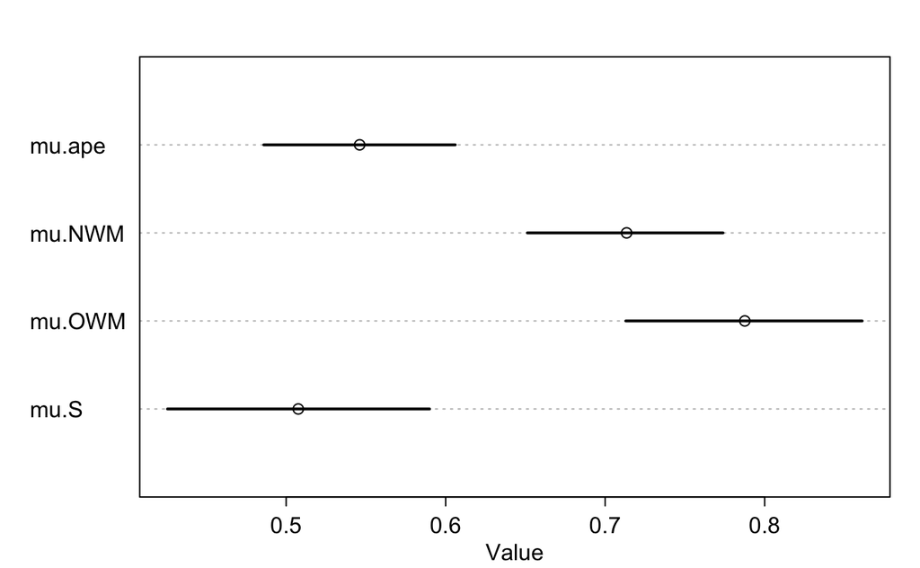

```r
plot(precis(select(post, mu.ape:mu.S)))
```

Using the samples, we can ask questions like *what’s the difference in means between the two monkey groups?*

```r
diff.NWM.OWM <- post$mu.NWM - post$mu.OWM
quantile(diff.NWM.OWM, probs = c(0.025, 0.975))
```

```
       2.5%       97.5%
-0.19049809  0.04478419
```

### Another approach: Unique intercepts

```r
d$clade_id <- factor(d$clade)
m5.16_alt <- rethinking::map(
  alist(
    kcal.per.g ~ dnorm(mu, sigma),
    mu <- a[clade_id],
    a[clade_id] ~ dnorm(0.6, 10),
    sigma ~ dunif(0, 10)
  ),
  data = d
)

precis(m5.16_alt, depth = 2)
```

|  | mean | sd | 5.5% | 94.5% |
| --- | --- | --- | --- | --- |
| a[1] | 0.55 | 0.04 | 0.48 | 0.61 |
| a[2] | 0.71 | 0.04 | 0.65 | 0.78 |
| a[3] | 0.79 | 0.05 | 0.71 | 0.86 |
| a[4] | 0.51 | 0.05 | 0.43 | 0.59 |
| sigma | 0.11 | 0.02 | 0.09 | 0.14 |

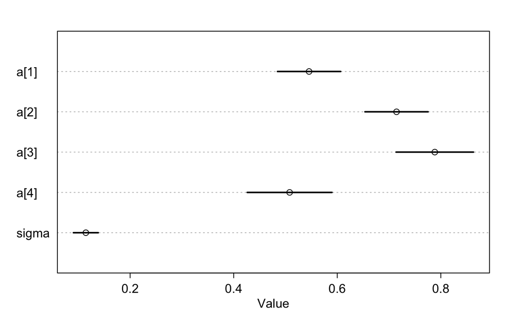

```r
plot(precis(m5.16_alt, depth = 2))
```

## Exercises

### Easy

5E1 2 and 4 are multiple linear regressions

5E2 $diversity_{animal} \sim 1 + latitude + diversity_{plant}$

5E3 $time_{phd} \sim funding + size_{lab}$. Both $\beta_f$ and $\beta_s$ should be positive.

S34 The inferentially equivalent models are 2, 3, 4, and 5.

### Medium

5M1

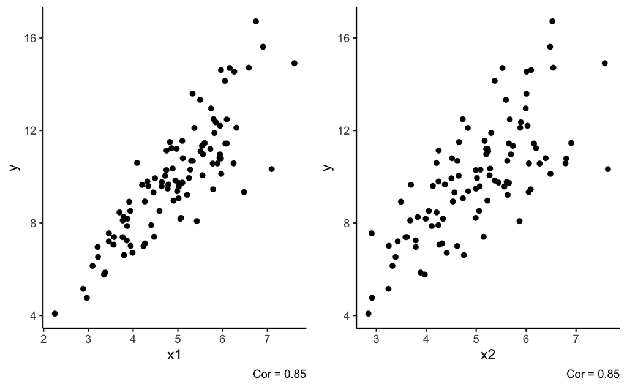

```r
N <- 100
d <- tibble(
  x1 = rnorm(N, 5, 1),
  x2 = x1 + rnorm(N, 0, 0.5),
  alpha = dnorm(N, 2, 1),
  mu = rnorm(N, 2, 0.25),
  y = alpha + mu * x1
)

plot_grid(
  ggplot(d, aes(x1, y)) +
    geom_point() +
    labs(caption = sprintf("Cor = %0.2f", cor(d$x1, d$y))) +
    theme_classic(),
  ggplot(d, aes(x2, y)) +
    geom_point() +
    labs(caption = sprintf("Cor = %0.2f", cor(d$x1, d$y))) +
    theme_classic()
)
```

```r
m5m1_single <- rethinking::map(
  alist(
    y ~ dnorm(mu, sigma),
    mu <- a + b1 * x1,
    c(a, b1) ~ dnorm(0, 10),
    sigma ~ dunif(0, 10)
  ),
  data = d
)

precis(m5m1_single)
```

|  | mean | sd | 5.5% | 94.5% |
| --- | --- | --- | --- | --- |
| a | 0.10 | 0.63 | -0.90 | 1.10 |
| b1 | 1.99 | 0.12 | 1.79 | 2.19 |
| sigma | 1.30 | 0.09 | 1.15 | 1.44 |

```r
m5m1 <- rethinking::map(
  alist(
    y ~ dnorm(mu, sigma),
    mu <- a + b1 * x1 + b2 * x2,
    c(a, b1, b2) ~ dnorm(0, 10),
    sigma ~ dunif(0, 10)
  ),
  data = d
)

precis(m5m1)
```

|  | mean | sd | 5.5% | 94.5% |
| --- | --- | --- | --- | --- |
| a | 0.38 | 0.63 | -0.63 | 1.39 |
| b1 | 2.49 | 0.29 | 2.04 | 2.95 |
| b2 | -0.56 | 0.29 | -1.01 | -0.10 |
| sigma | 1.27 | 0.09 | 1.13 | 1.42 |

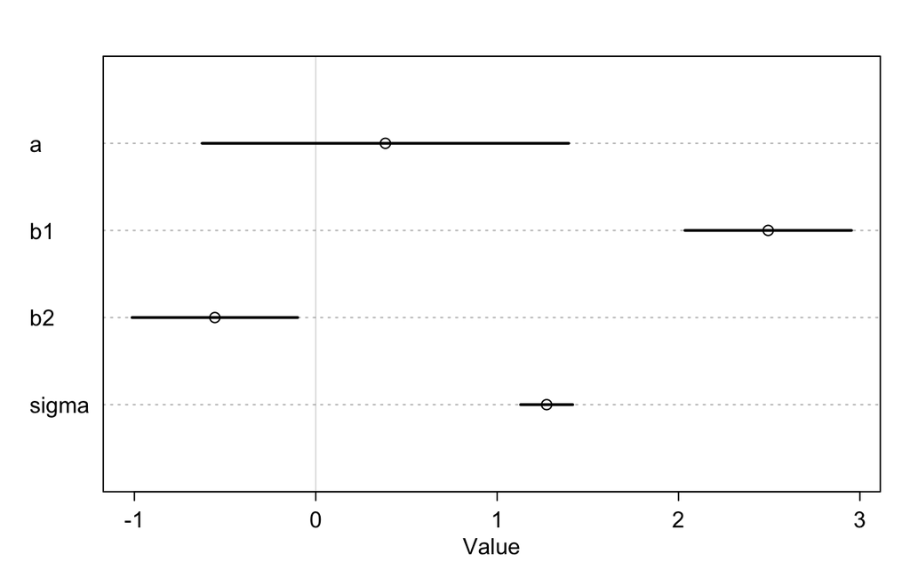

```r
plot(precis(m5m1))
```

5M2

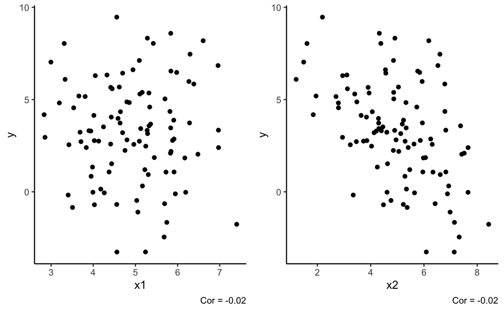

```r
N <- 100
d <- tibble(
  x1 = rnorm(N, 5, 1),
  x2 = x1 + rnorm(N, 0, 1),
  alpha = runif(N, 2, 4),
  mu1 = rnorm(N, 2, 0.25),
  mu2 = rnorm(N, -2, 0.25),
  y = alpha + mu1 * x1 + mu2 * x2
)

plot_grid(
  ggplot(d, aes(x1, y)) +
    geom_point() +
    labs(caption = sprintf("Cor = %0.2f", cor(d$x1, d$y))) +
    theme_classic(),
  ggplot(d, aes(x2, y)) +
    geom_point() +
    labs(caption = sprintf("Cor = %0.2f", cor(d$x1, d$y))) +
    theme_classic()
)
```

```r
m5m2 <- rethinking::map(
  alist(
    y ~ dnorm(mu, sigma),
    mu <- a + b1 * x1 + b2 * x2,
    c(a, b1, b2) ~ dnorm(0, 10),
    sigma ~ dunif(0, 10)
  ),
  data = d
)

precis(m5m2)
```

|  | mean | sd | 5.5% | 94.5% |
| --- | --- | --- | --- | --- |
| a | 1.86 | 0.97 | 0.31 | 3.42 |
| b1 | 2.31 | 0.30 | 1.83 | 2.79 |
| b2 | -2.00 | 0.20 | -2.32 | -1.69 |
| sigma | 1.92 | 0.14 | 1.70 | 2.13 |

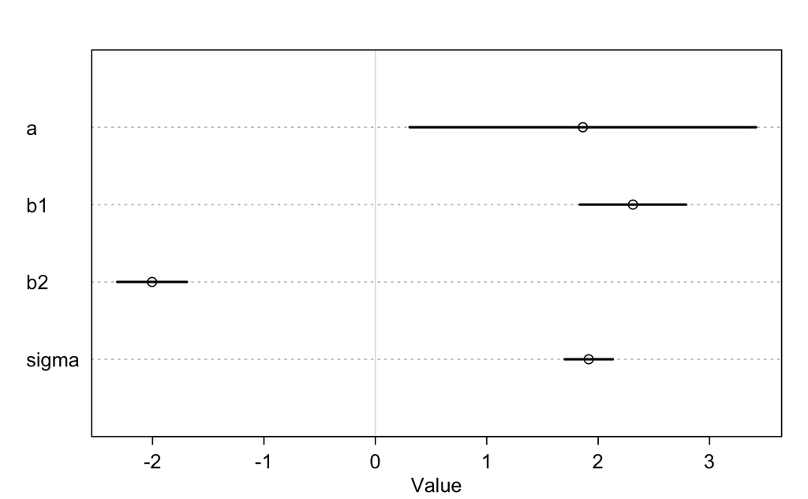

```r
plot(precis(m5m2))
```

5m3 ???

5m4 Not going to look up LDS numbers

5m5

Is obesity associated with the price of gas after accounting for frequency of eating out?

$obesity_i \sim \alpha + \beta_g \times gas + \beta_r \times restaurant$

Is obesity associated with the price of gas after accounting for hours walking?

$obesity_i \sim \alpha + \beta_g \times gas + \beta_w \times walking$

### Hard

```r
data(foxes)
str(foxes)
```

```
'data.frame':   116 obs. of  5 variables:
 $ group    : int  1 1 2 2 3 3 4 4 5 5 ...
 $ avgfood  : num  0.37 0.37 0.53 0.53 0.49 0.49 0.45 0.45 0.74 0.74 ...
 $ groupsize: int  2 2 2 2 2 2 2 2 3 3 ...
 $ area     : num  1.09 1.09 2.05 2.05 2.12 2.12 1.29 1.29 3.78 3.78 ...
 $ weight   : num  5.02 2.84 5.33 6.07 5.85 3.25 4.53 4.09 6.13 5.59 ...
```

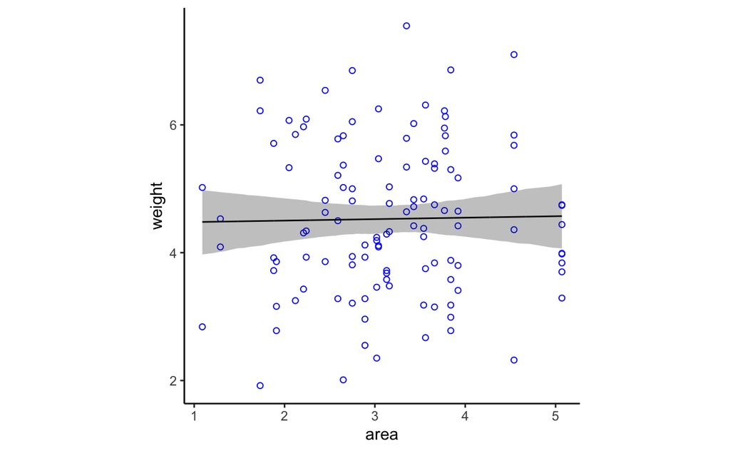

```r
# weight ~ area
m5h1a <- rethinking::map(
  alist(
    weight ~ dnorm(mu, sigma),
    mu <- a + b * area,
    a ~ dnorm(0, 10),
    b ~ dnorm(0, 2),
    sigma ~ dunif(0, 10)
  ),
  data = foxes
)

area.seq <- seq(min(foxes$area), max(foxes$area), length.out = 1e3)
area.link <- link(m5h1a, tibble(area = area.seq), n = 1e3)
area.mu <- apply(area.link, 2, mean)
area.pi <- apply(area.link, 2, PI, 0.95)
pred.data <- tibble(
  area = area.seq,
  weight = area.mu,
  weight.low = area.pi[1, ],
  weight.hi = area.pi[2, ]
)

ggplot(foxes, aes(area, weight)) +
  geom_point(shape = 21, color = "blue") +
  geom_line(data = pred.data) +
  geom_ribbon(aes(ymin = weight.low, ymax = weight.hi),
              data = pred.data,
              alpha = 0.3) +
  theme_classic() +
  theme(aspect.ratio = 1)
```

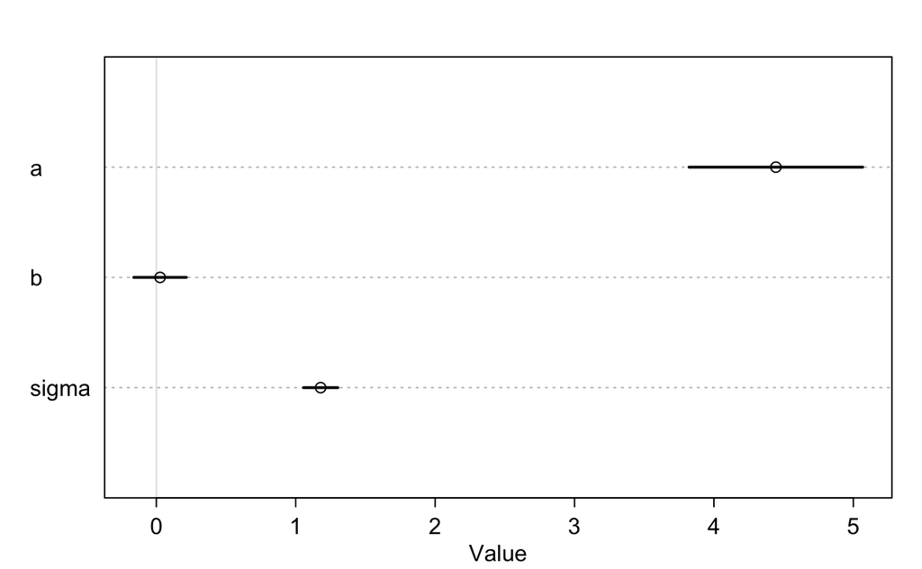

```r
plot(precis(m5h1a))
```

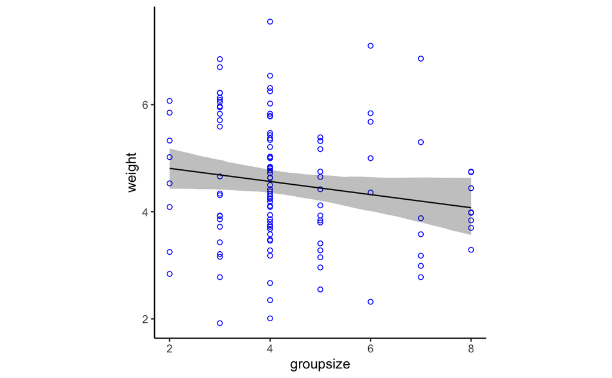

```r
# weight ~ groupsize
m5h1b <- rethinking::map(
  alist(
    weight ~ dnorm(mu, sigma),
    mu <- a + b * groupsize,
    a ~ dnorm(0, 10),
    b ~ dnorm(0, 2),
    sigma ~ dunif(0, 10)
  ),
  data = foxes
)

groupsize.seq <- seq(min(foxes$groupsize),
                     max(foxes$groupsize),
                     length.out = 1e3)
groupsize.link <- link(m5h1b, tibble(groupsize = groupsize.seq), n = 1e3)
groupsize.mu <- apply(groupsize.link, 2, mean)
groupsize.pi <- apply(groupsize.link, 2, PI, 0.95)
pred.data <- tibble(
  groupsize = groupsize.seq,
  weight = groupsize.mu,
  weight.low = groupsize.pi[1, ],
  weight.hi = groupsize.pi[2, ]
)

ggplot(foxes, aes(groupsize, weight)) +
  geom_point(shape = 21, color = "blue") +
  geom_line(data = pred.data) +
  geom_ribbon(aes(ymin = weight.low, ymax = weight.hi),
              data = pred.data,
              alpha = 0.3) +
  theme_classic() +
  theme(aspect.ratio = 1)
```

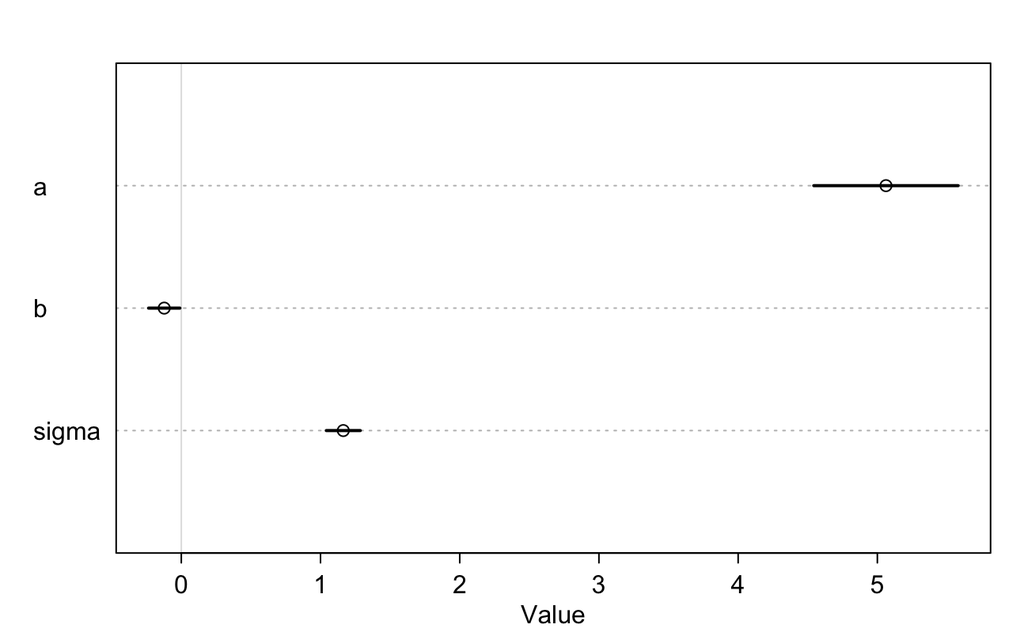

```r
plot(precis(m5h1b))
```

In the bivariate regressions, both slopes are very similar to 0.

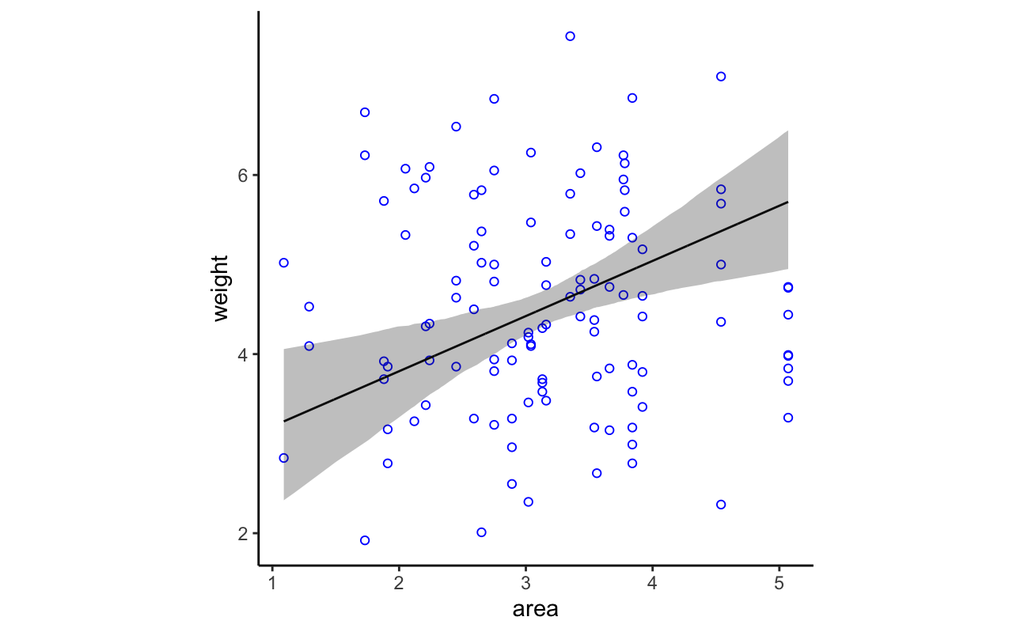

```r
# weight ~ area + groupsize
m5h2 <- rethinking::map(
  alist(
    weight ~ dnorm(mu, sigma),
    mu <- a + ba * area + bg * groupsize,
    a ~ dnorm(0, 10),
    c(ba, bg) ~ dnorm(0, 2),
    sigma ~ dunif(0, 10)
  ),
  data = foxes
)

# Area w.r.t mean(groupsize)
area.seq <- seq(min(foxes$area), max(foxes$area), length.out = 1e3)
area.link <- link(
  m5h2,
  tibble(area = area.seq, groupsize = mean(foxes$groupsize)),
  n = 1e3
)
area.mu <- apply(area.link, 2, mean)
area.pi <- apply(area.link, 2, PI, 0.95)
pred.area <- tibble(
  area = area.seq,
  weight = area.mu,
  weight.low = area.pi[1, ],
  weight.hi = area.pi[2, ]
)

ggplot(foxes, aes(area, weight)) +
  geom_point(shape = 21, color = "blue") +
  geom_line(data = pred.area) +
  geom_ribbon(aes(ymin = weight.low, ymax = weight.hi),
              data = pred.area,
              alpha = 0.3) +
  theme_classic() +
  theme(aspect.ratio = 1)
```

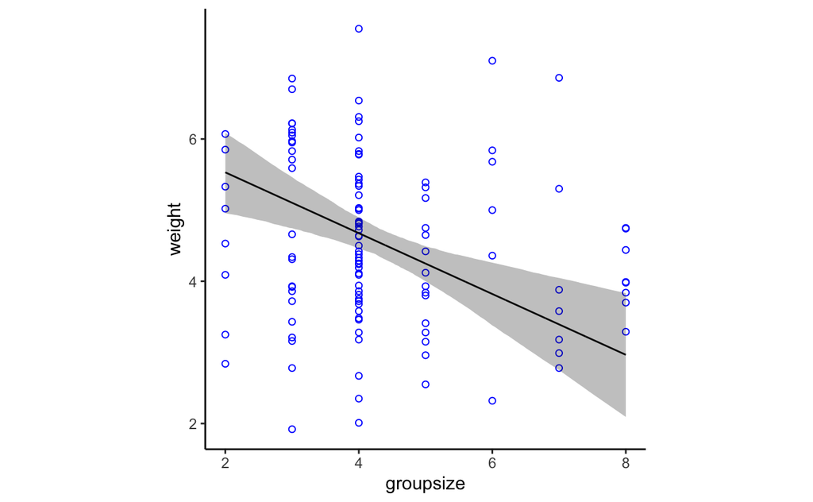

```r
# Groupsize w.r.t mean(area)
groupsize.seq <- seq(min(foxes$groupsize),
                     max(foxes$groupsize),
                     length.out = 1e3)
groupsize.link <- link(
  m5h2,
  tibble(groupsize = groupsize.seq, area = mean(foxes$area)),
  n = 1e3
)
groupsize.mu <- apply(groupsize.link, 2, mean)
groupsize.pi <- apply(groupsize.link, 2, PI, 0.95)
pred.groupsize <- tibble(
  groupsize = groupsize.seq,
  weight = groupsize.mu,
  weight.low = groupsize.pi[1, ],
  weight.hi = groupsize.pi[2, ]
)

ggplot(foxes, aes(groupsize, weight)) +
  geom_point(shape = 21, color = "blue") +
  geom_line(data = pred.groupsize) +
  geom_ribbon(aes(ymin = weight.low, ymax = weight.hi),
              data = pred.groupsize,
              alpha = 0.3) +
  theme_classic() +
  theme(aspect.ratio = 1)
```

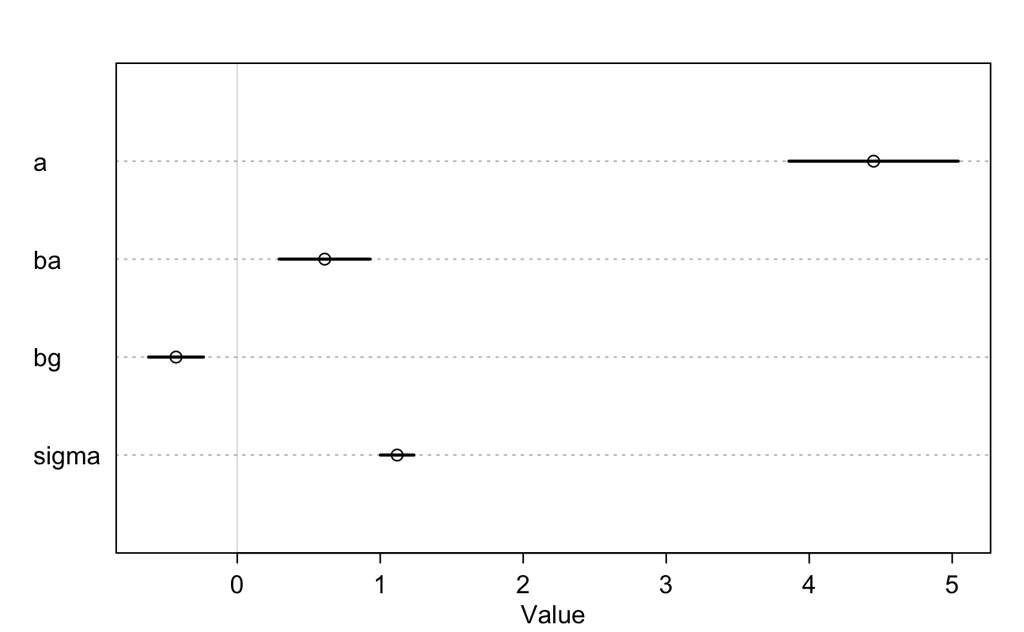

```r
plot(precis(m5h2))
```

Both coefficients now have greater magnitudes. Area and groupsize are positively correlated (cor = 0.83) but weight is correlated positively with area and negatively with groupsize when both are taken into account. This is an example of a masked relationship.

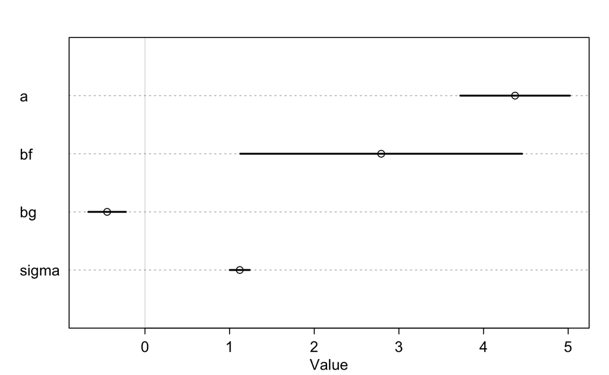

```r
# weight ~ avgfood + groupsize
m5h3a <- rethinking::map(
  alist(
    weight ~ dnorm(mu, sigma),
    mu <- a + bf * avgfood + bg * groupsize,
    a ~ dnorm(0, 10),
    c(bf, bg) ~ dnorm(0, 2),
    sigma ~ dunif(0, 10)
  ),
  data = foxes
)

plot(precis(m5h3a))
```